# Group_4_Sprint_3_Development_v3

Artificial Intelligence for Business Decisions and Transformation

CSCN8030 - Spring 2024 - Section 2

Professor: Glaucia Melo dos Santos, PhD

Group 4 - Members:

Krishna Kumar, Hemasree  
Shijin, Jency  
Fernandez, Arcadio

## Sprint 3 Development:

# Project: Crop Yield Prediction using ML

# 1. A brief introduction to the problem

Crop Yield Prediction Dataset

Predicting crop yield of 10 most consumed crops in 🌏

The Crop Yield Prediction project aims to predict the yield of different crops based on various environmental and agricultural factors. This project is crucial for agricultural planning, resource allocation, and ensuring food security. Accurate predictions can help farmers and policymakers make informed decisions about crop management, irrigation, and pest control strategies.

The dataset contains historical data on crop yield from year 1990 to 2013 along with several features such as:

1. Area: The geographical area (country) where the crop is grown.
2. Year: The year of the recorded data.
3. Crop_Name: The name of the crop.
4. yield_in_hg/ha: The yield of the crop in hectograms per hectare.
5. total_pesticides_in_tonnes: The total amount of pesticides used in tonnes.
6. average_rain_fall_mm_per_year: The average annual rainfall in millimeters.
7. avg_temp: The average temperature in degrees Celsius.
8. Area Code: The code representing the geographical area.
9. Item Code: The code representing the crop.

On Kaggle at Crop Yield Prediction Dataset, there are 33 codes, and two caught our attention because of their organization and the good results they exposed:

https://www.kaggle.com/code/patelris/crop-yield-eda-viz

https://www.kaggle.com/code/mahmoudmagdyelnahal/crop-yield-prediction-99

# 2. Libraries and data

## 2.1 Importing the libraries

```python
import numpy as np
import pandas as pd
import matplotlib.pyplot as plt
import seaborn as sns
```

## 2.2. Obtaining the Data

```python
df_pesticides = pd.read_csv(r"C:\Users\arcad\Labs_term2\Crop Yield Prediction\archive\pesticides.csv")
df_rainfall = pd.read_csv(r"C:\Users\arcad\Labs_term2\Crop Yield Prediction\archive\rainfall.csv")
df_temp = pd.read_csv(r"C:\Users\arcad\Labs_term2\Crop Yield Prediction\archive\temp.csv")
df_yield = pd.read_csv(r"C:\Users\arcad\Labs_term2\Crop Yield Prediction\archive\yield.csv")
```

```python
display(df_pesticides)
```

|  | Domain | Area | Element | Item | Year | Unit | Value |
| --- | --- | --- | --- | --- | --- | --- | --- |
| 0 | Pesticides Use | Albania | Use | Pesticides (total) | 1990 | tonnes of active ingredients | 121.00 |
| 1 | Pesticides Use | Albania | Use | Pesticides (total) | 1991 | tonnes of active ingredients | 121.00 |
| 2 | Pesticides Use | Albania | Use | Pesticides (total) | 1992 | tonnes of active ingredients | 121.00 |
| 3 | Pesticides Use | Albania | Use | Pesticides (total) | 1993 | tonnes of active ingredients | 121.00 |
| 4 | Pesticides Use | Albania | Use | Pesticides (total) | 1994 | tonnes of active ingredients | 201.00 |
| ... | ... | ... | ... | ... | ... | ... | ... |
| 4344 | Pesticides Use | Zimbabwe | Use | Pesticides (total) | 2012 | tonnes of active ingredients | 3375.53 |
| 4345 | Pesticides Use | Zimbabwe | Use | Pesticides (total) | 2013 | tonnes of active ingredients | 2550.07 |
| 4346 | Pesticides Use | Zimbabwe | Use | Pesticides (total) | 2014 | tonnes of active ingredients | 2185.07 |
| 4347 | Pesticides Use | Zimbabwe | Use | Pesticides (total) | 2015 | tonnes of active ingredients | 2185.07 |
| 4348 | Pesticides Use | Zimbabwe | Use | Pesticides (total) | 2016 | tonnes of active ingredients | 2185.07 |

4349 rows × 7 columns

```python
df_rainfall
```

|  | Area | Year | average_rain_fall_mm_per_year |
| --- | --- | --- | --- |
| 0 | Afghanistan | 1985 | 327 |
| 1 | Afghanistan | 1986 | 327 |
| 2 | Afghanistan | 1987 | 327 |
| 3 | Afghanistan | 1989 | 327 |
| 4 | Afghanistan | 1990 | 327 |
| ... | ... | ... | ... |
| 6722 | Zimbabwe | 2013 | 657 |
| 6723 | Zimbabwe | 2014 | 657 |
| 6724 | Zimbabwe | 2015 | 657 |
| 6725 | Zimbabwe | 2016 | 657 |
| 6726 | Zimbabwe | 2017 | 657 |

6727 rows × 3 columns

```python
df_rainfall = df_rainfall.rename(columns={' Area': 'Area'})
```

```python
df_rainfall.dropna(inplace=True)
```

```python
display(df_temp)
```

|  | year | country | avg_temp |
| --- | --- | --- | --- |
| 0 | 1849 | Côte D'Ivoire | 25.58 |
| 1 | 1850 | Côte D'Ivoire | 25.52 |
| 2 | 1851 | Côte D'Ivoire | 25.67 |
| 3 | 1852 | Côte D'Ivoire | NaN |
| 4 | 1853 | Côte D'Ivoire | NaN |
| ... | ... | ... | ... |
| 71306 | 2009 | Mexico | 21.76 |
| 71307 | 2010 | Mexico | 20.90 |
| 71308 | 2011 | Mexico | 21.55 |
| 71309 | 2012 | Mexico | 21.52 |
| 71310 | 2013 | Mexico | 22.19 |

71311 rows × 3 columns

```python
df_temp = df_temp.rename(columns={'country': 'Area','year':'Year'})
```

```python
display(df_yield)
```

|  | Domain Code | Domain | Area Code | Area | Element Code | Element | Item Code | Item | Year Code | Year | Unit | Value |
| --- | --- | --- | --- | --- | --- | --- | --- | --- | --- | --- | --- | --- |
| 0 | QC | Crops | 2 | Afghanistan | 5419 | Yield | 56 | Maize | 1961 | 1961 | hg/ha | 14000 |
| 1 | QC | Crops | 2 | Afghanistan | 5419 | Yield | 56 | Maize | 1962 | 1962 | hg/ha | 14000 |
| 2 | QC | Crops | 2 | Afghanistan | 5419 | Yield | 56 | Maize | 1963 | 1963 | hg/ha | 14260 |
| 3 | QC | Crops | 2 | Afghanistan | 5419 | Yield | 56 | Maize | 1964 | 1964 | hg/ha | 14257 |
| 4 | QC | Crops | 2 | Afghanistan | 5419 | Yield | 56 | Maize | 1965 | 1965 | hg/ha | 14400 |
| ... | ... | ... | ... | ... | ... | ... | ... | ... | ... | ... | ... | ... |
| 56712 | QC | Crops | 181 | Zimbabwe | 5419 | Yield | 15 | Wheat | 2012 | 2012 | hg/ha | 24420 |
| 56713 | QC | Crops | 181 | Zimbabwe | 5419 | Yield | 15 | Wheat | 2013 | 2013 | hg/ha | 22888 |
| 56714 | QC | Crops | 181 | Zimbabwe | 5419 | Yield | 15 | Wheat | 2014 | 2014 | hg/ha | 21357 |
| 56715 | QC | Crops | 181 | Zimbabwe | 5419 | Yield | 15 | Wheat | 2015 | 2015 | hg/ha | 19826 |
| 56716 | QC | Crops | 181 | Zimbabwe | 5419 | Yield | 15 | Wheat | 2016 | 2016 | hg/ha | 18294 |

56717 rows × 12 columns

## 2.3. Data Integration

```python
merged_df = pd.merge(df_pesticides, df_rainfall, on=['Area', 'Year'], how='inner')
```

```python
merged_df = pd.merge(merged_df,df_temp,on=['Area', 'Year'], how='inner')
```

```python
df_crop_yield = pd.merge(merged_df,df_yield,on=['Area', 'Year'], how='inner')
```

```python
display(df_crop_yield)
```

|  | Domain_x | Area | Element_x | Item_x | Year | Unit_x | Value_x | average_rain_fall_mm_per_year | avg_temp | Domain Code | Domain_y | Area Code | Element Code | Element_y | Item Code | Item_y | Year Code | Unit_y | Value_y |
| --- | --- | --- | --- | --- | --- | --- | --- | --- | --- | --- | --- | --- | --- | --- | --- | --- | --- | --- | --- |
| 0 | Pesticides Use | Albania | Use | Pesticides (total) | 1990 | tonnes of active ingredients | 121.00 | 1485 | 16.37 | QC | Crops | 3 | 5419 | Yield | 56 | Maize | 1990 | hg/ha | 36613 |
| 1 | Pesticides Use | Albania | Use | Pesticides (total) | 1990 | tonnes of active ingredients | 121.00 | 1485 | 16.37 | QC | Crops | 3 | 5419 | Yield | 116 | Potatoes | 1990 | hg/ha | 66667 |
| 2 | Pesticides Use | Albania | Use | Pesticides (total) | 1990 | tonnes of active ingredients | 121.00 | 1485 | 16.37 | QC | Crops | 3 | 5419 | Yield | 27 | Rice, paddy | 1990 | hg/ha | 23333 |
| 3 | Pesticides Use | Albania | Use | Pesticides (total) | 1990 | tonnes of active ingredients | 121.00 | 1485 | 16.37 | QC | Crops | 3 | 5419 | Yield | 83 | Sorghum | 1990 | hg/ha | 12500 |
| 4 | Pesticides Use | Albania | Use | Pesticides (total) | 1990 | tonnes of active ingredients | 121.00 | 1485 | 16.37 | QC | Crops | 3 | 5419 | Yield | 236 | Soybeans | 1990 | hg/ha | 7000 |
| ... | ... | ... | ... | ... | ... | ... | ... | ... | ... | ... | ... | ... | ... | ... | ... | ... | ... | ... | ... |
| 28243 | Pesticides Use | Zimbabwe | Use | Pesticides (total) | 2013 | tonnes of active ingredients | 2550.07 | 657 | 19.76 | QC | Crops | 181 | 5419 | Yield | 27 | Rice, paddy | 2013 | hg/ha | 22581 |
| 28244 | Pesticides Use | Zimbabwe | Use | Pesticides (total) | 2013 | tonnes of active ingredients | 2550.07 | 657 | 19.76 | QC | Crops | 181 | 5419 | Yield | 83 | Sorghum | 2013 | hg/ha | 3066 |
| 28245 | Pesticides Use | Zimbabwe | Use | Pesticides (total) | 2013 | tonnes of active ingredients | 2550.07 | 657 | 19.76 | QC | Crops | 181 | 5419 | Yield | 236 | Soybeans | 2013 | hg/ha | 13142 |
| 28246 | Pesticides Use | Zimbabwe | Use | Pesticides (total) | 2013 | tonnes of active ingredients | 2550.07 | 657 | 19.76 | QC | Crops | 181 | 5419 | Yield | 122 | Sweet potatoes | 2013 | hg/ha | 22222 |
| 28247 | Pesticides Use | Zimbabwe | Use | Pesticides (total) | 2013 | tonnes of active ingredients | 2550.07 | 657 | 19.76 | QC | Crops | 181 | 5419 | Yield | 15 | Wheat | 2013 | hg/ha | 22888 |

28248 rows × 19 columns

```python
df_crop_yield.columns
```

```
Index(['Domain_x', 'Area', 'Element_x', 'Item_x', 'Year', 'Unit_x', 'Value_x',
       'average_rain_fall_mm_per_year', 'avg_temp', 'Domain Code', 'Domain_y',
       'Area Code', 'Element Code', 'Element_y', 'Item Code', 'Item_y',
       'Year Code', 'Unit_y', 'Value_y'],
      dtype='object')
```

```python
df_crop_yield.drop(columns=['Domain_x','Element_x','Item_x','Unit_x','Domain Code','Domain_y','Element Code','Element_y','Year Code','Unit_y'],inplace= True)
```

```python
df_crop_yield = df_crop_yield.rename(columns={'Value_x': 'total_pesticides_in_tonnes','Value_y':'yield_in_hg/ha','Item_y':'Crop_Name'})
```

```python
display(df_crop_yield)
```

|  | Area | Year | total_pesticides_in_tonnes | average_rain_fall_mm_per_year | avg_temp | Area Code | Item Code | Crop_Name | yield_in_hg/ha |
| --- | --- | --- | --- | --- | --- | --- | --- | --- | --- |
| 0 | Albania | 1990 | 121.00 | 1485 | 16.37 | 3 | 56 | Maize | 36613 |
| 1 | Albania | 1990 | 121.00 | 1485 | 16.37 | 3 | 116 | Potatoes | 66667 |
| 2 | Albania | 1990 | 121.00 | 1485 | 16.37 | 3 | 27 | Rice, paddy | 23333 |
| 3 | Albania | 1990 | 121.00 | 1485 | 16.37 | 3 | 83 | Sorghum | 12500 |
| 4 | Albania | 1990 | 121.00 | 1485 | 16.37 | 3 | 236 | Soybeans | 7000 |
| ... | ... | ... | ... | ... | ... | ... | ... | ... | ... |
| 28243 | Zimbabwe | 2013 | 2550.07 | 657 | 19.76 | 181 | 27 | Rice, paddy | 22581 |
| 28244 | Zimbabwe | 2013 | 2550.07 | 657 | 19.76 | 181 | 83 | Sorghum | 3066 |
| 28245 | Zimbabwe | 2013 | 2550.07 | 657 | 19.76 | 181 | 236 | Soybeans | 13142 |
| 28246 | Zimbabwe | 2013 | 2550.07 | 657 | 19.76 | 181 | 122 | Sweet potatoes | 22222 |
| 28247 | Zimbabwe | 2013 | 2550.07 | 657 | 19.76 | 181 | 15 | Wheat | 22888 |

28248 rows × 9 columns

# 3.Data Pre-processing

## 3.1. Checking for Missing values

```python
display(df_crop_yield.isnull().sum())
```

```
Area                             0
Year                             0
total_pesticides_in_tonnes       0
average_rain_fall_mm_per_year    0
avg_temp                         0
Area Code                        0
Item Code                        0
Crop_Name                        0
yield_in_hg/ha                   0
dtype: int64
```

```python
df_crop_yield['average_rain_fall_mm_per_year'] = pd.to_numeric(df_crop_yield['average_rain_fall_mm_per_year'],errors = 'coerce')
```

```python
df_crop_yield.info()
```

```
<class 'pandas.core.frame.DataFrame'>
RangeIndex: 28248 entries, 0 to 28247
Data columns (total 9 columns):
 #   Column                         Non-Null Count  Dtype
---  ------                         --------------  -----
 0   Area                           28248 non-null  object
 1   Year                           28248 non-null  int64
 2   total_pesticides_in_tonnes     28248 non-null  float64
 3   average_rain_fall_mm_per_year  28242 non-null  float64
 4   avg_temp                       28248 non-null  float64
 5   Area Code                      28248 non-null  int64
 6   Item Code                      28248 non-null  int64
 7   Crop_Name                      28248 non-null  object
 8   yield_in_hg/ha                 28248 non-null  int64
dtypes: float64(3), int64(4), object(2)
memory usage: 1.9+ MB
```

# 4.Exploratory Data Analysis

## 4.1. Plotting the Top 10 countries which has the highest total crop yield

```python
# Group by Area to calculate the total yield
total_yield = df_crop_yield.groupby('Area')['yield_in_hg/ha'].sum().reset_index()

# Get the top 10 countries with the highest average yield
top_10_countries = total_yield.nlargest(10, 'yield_in_hg/ha')['Area'].tolist()

# Filter the original DataFrame to include only the top 10 countries
top_10_df = df_crop_yield[df_crop_yield['Area'].isin(top_10_countries)]
```

```python
top_10_countries
```

```
['India',
 'Brazil',
 'Mexico',
 'Japan',
 'Australia',
 'Pakistan',
 'Indonesia',
 'United Kingdom',
 'Turkey',
 'Spain']
```

```python
top_10_aggregate_yield = top_10_df.groupby('Area')['yield_in_hg/ha'].sum().reset_index()
```

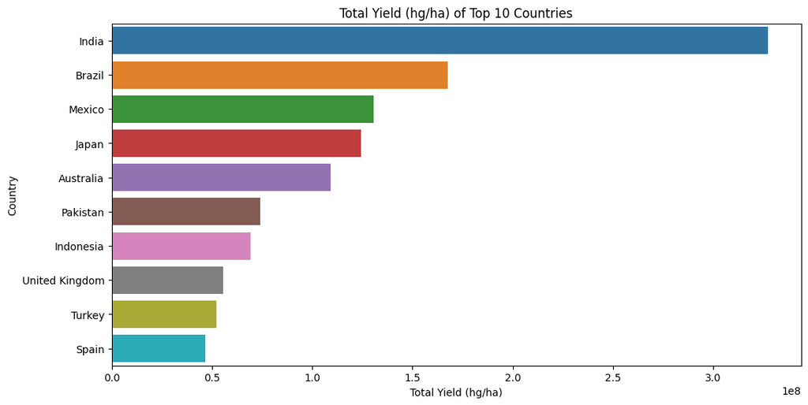

```python
plt.figure(figsize=(12, 6))
sns.barplot(x='yield_in_hg/ha', y='Area', data=top_10_aggregate_yield.sort_values(by='yield_in_hg/ha', ascending=False))
plt.title('Total Yield (hg/ha) of Top 10 Countries')
plt.xlabel('Total Yield (hg/ha)')
plt.ylabel('Country')
plt.show()
```

## 4.2. Plotting the yield over the years for Top 10 countries

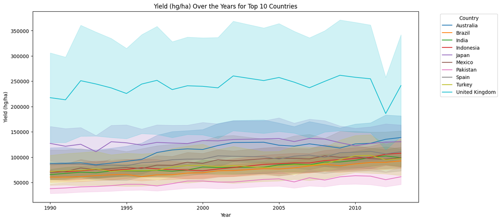

```python
plt.figure(figsize=(14, 7))
sns.lineplot(data=top_10_df, x='Year', y='yield_in_hg/ha', hue='Area')
plt.title('Yield (hg/ha) Over the Years for Top 10 Countries')
plt.xlabel('Year')
plt.ylabel('Yield (hg/ha)')
plt.legend(title='Country', bbox_to_anchor=(1.05, 1), loc='upper left')
plt.show()
```

## 4.3. Country with the highest total yield for each crop

```python
total_yield = df_crop_yield.groupby(['Crop_Name', 'Area'])['yield_in_hg/ha'].sum().reset_index()
```

```python
highest_total_yield = total_yield.loc[total_yield.groupby('Crop_Name')['yield_in_hg/ha'].idxmax()].reset_index(drop=True)
```

```python
highest_total_yield
```

|  | Crop_Name | Area | yield_in_hg/ha |
| --- | --- | --- | --- |
| 0 | Cassava | India | 142810624 |
| 1 | Maize | Canada | 10721406 |
| 2 | Plantains and others | Guatemala | 6695215 |
| 3 | Potatoes | India | 92122514 |
| 4 | Rice, paddy | India | 15329644 |
| 5 | Sorghum | Mexico | 6222416 |
| 6 | Soybeans | Brazil | 6113646 |
| 7 | Sweet potatoes | India | 44439538 |
| 8 | Wheat | India | 13432694 |
| 9 | Yams | Japan | 29165394 |

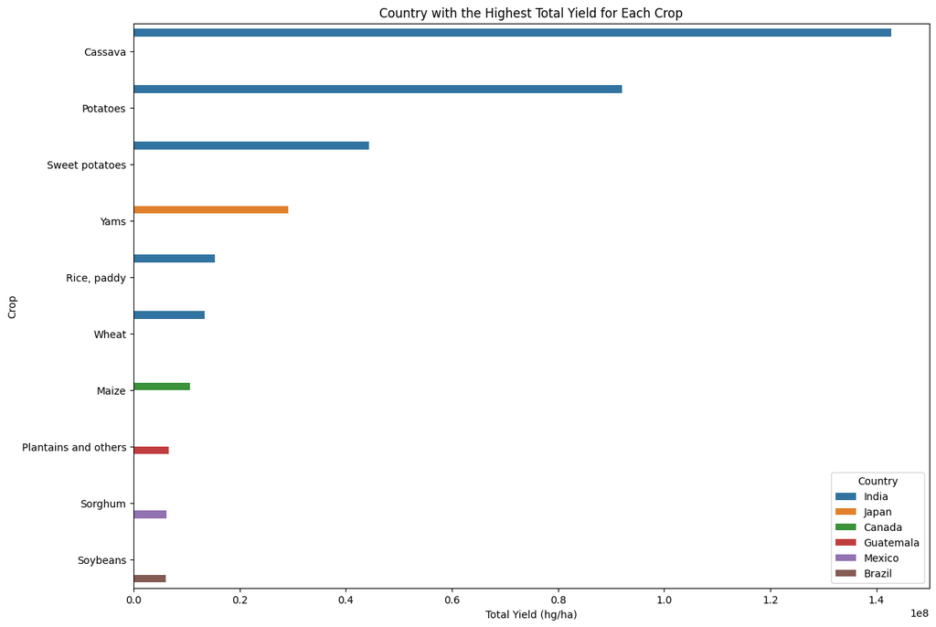

```python
plt.figure(figsize=(14, 10))
sns.barplot(x='yield_in_hg/ha', y='Crop_Name', hue='Area', data=highest_total_yield.sort_values(by='yield_in_hg/ha', ascending=False))
plt.title('Country with the Highest Total Yield for Each Crop')
plt.xlabel('Total Yield (hg/ha)')
plt.ylabel('Crop')
plt.legend(title='Country')
plt.show()
```

## 4.4. Pairplot to show the pairwise relationship between variables

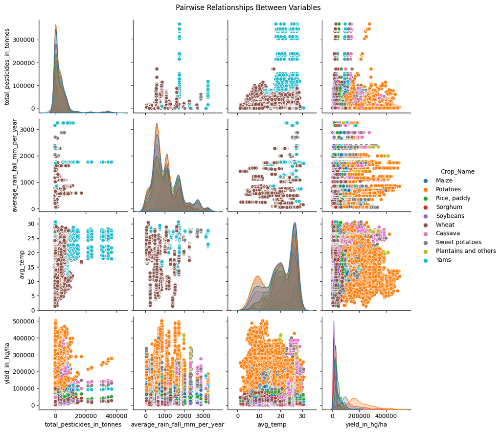

```python
sns.pairplot(df_crop_yield[['total_pesticides_in_tonnes', 'average_rain_fall_mm_per_year', 'avg_temp', 'yield_in_hg/ha', 'Crop_Name']], hue='Crop_Name')
plt.suptitle('Pairwise Relationships Between Variables', y=1.02)
plt.show()
```

# 5. Feature Engineering

## 5.1. Dropping NA values:

```python
# Check for NA values in the DataFrame
df_na_counts = df_crop_yield.isna().sum()
```

```python
df_na_counts
```

```
Area                             0
Year                             0
total_pesticides_in_tonnes       0
average_rain_fall_mm_per_year    6
avg_temp                         0
Area Code                        0
Item Code                        0
Crop_Name                        0
yield_in_hg/ha                   0
dtype: int64
```

```python
# Drop rows with any missing values
df_crop_yield = df_crop_yield.dropna()
```

## 5.2. Remove countries with less than 100 records:

```python
# check countries with less than 100 records
country_count =df_crop_yield['Area'].value_counts()
drop_list = country_count[country_count < 100].index.tolist()
drop_list
```

```
['Albania',
 'Austria',
 'Malaysia',
 'Lesotho',
 'New Zealand',
 'Switzerland',
 'Lebanon',
 'Slovenia',
 'Namibia',
 'Eritrea',
 'Poland',
 'Netherlands',
 'Tunisia',
 'Qatar',
 'Bahamas',
 'Botswana',
 'Belarus',
 'Lithuania',
 'Armenia',
 'Denmark',
 'Sweden',
 'Norway',
 'Finland',
 'Ireland',
 'Latvia',
 'Estonia',
 'Belgium',
 'Bahrain',
 'Sudan',
 'Montenegro']
```

```python
df_crop_yield = df_crop_yield[~df_crop_yield['Area'].isin(drop_list)]
df_crop_yield = df_crop_yield.reset_index(drop=True)
```

## 5.3. Generate new features to facilitate prediction.

```python
# rain_avg_temp - capture the combined effect of  two environmental factors avg_temp and average_rain_fall_mm_per_year on crop yield
df_crop_yield['rain_avg_temp']= df_crop_yield['avg_temp'] * df_crop_yield['average_rain_fall_mm_per_year']


# pesticide_avg_rain - provides a measure of pesticide usage relative to rainfall
df_crop_yield['pesticide_avg_rain']= np.log(df_crop_yield['total_pesticides_in_tonnes'] / df_crop_yield['average_rain_fall_mm_per_year'])


# pesticide_avg_temp - provides a measure of pesticide usage relative to temperature
df_crop_yield['pesticide_avg_temp']= np.log(df_crop_yield['total_pesticides_in_tonnes'] / df_crop_yield['avg_temp'])

# pesticide_temp_rain- combines the effects of temperature and rainfall on pesticide usage
df_crop_yield['pesticide_temp_rain']= (df_crop_yield['pesticide_avg_temp'] / df_crop_yield['pesticide_avg_rain'])

# avg_rain_log - help normalize the data and reduce the effect of extreme values
df_crop_yield['avg_rain_log'] = np.log(df_crop_yield['average_rain_fall_mm_per_year'])

# avg_temp_rain_log - capture the relative effect of temperature adjusted by the log of rainfall
df_crop_yield['avg_temp_rain_log']=df_crop_yield['avg_temp'] /  df_crop_yield['avg_rain_log']
```

## 5.4. Check Correlation Matrix:

```python
corr_matrix = df_crop_yield.select_dtypes(['int64','float64']).corr()
```

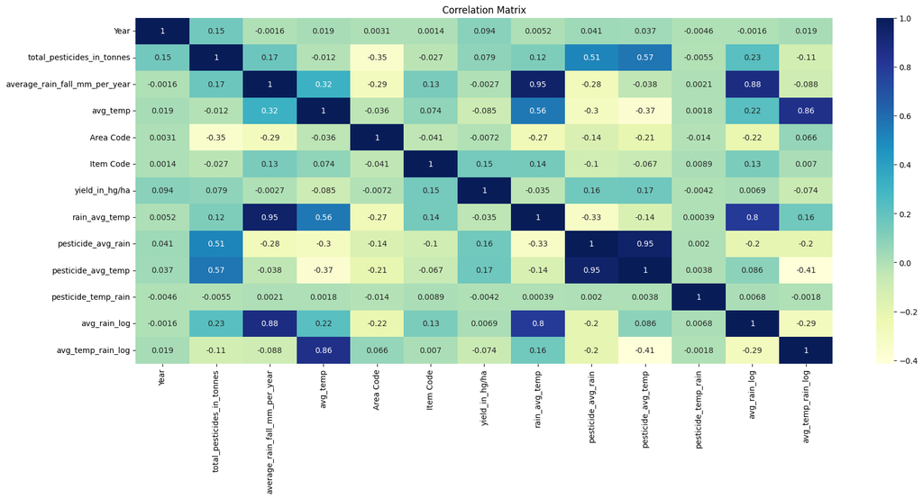

```python
plt.figure(figsize=(20, 8))
sns.heatmap(corr_matrix,cmap = 'YlGnBu',annot = True)
plt.title('Correlation Matrix')
```

```python
corr_matrix["yield_in_hg/ha"].sort_values(ascending=False)
```

```
yield_in_hg/ha                   1.000000
pesticide_avg_temp               0.166134
pesticide_avg_rain               0.157449
Item Code                        0.147408
Year                             0.093608
total_pesticides_in_tonnes       0.079318
avg_rain_log                     0.006885
average_rain_fall_mm_per_year   -0.002670
pesticide_temp_rain             -0.004154
Area Code                       -0.007198
rain_avg_temp                   -0.035039
avg_temp_rain_log               -0.073708
avg_temp                        -0.084683
Name: yield_in_hg/ha, dtype: float64
```

Considering the significant positive and negative correlations, the following features are the most relevant for modeling yield_in_hg/ha: Also removing features that have a high correlation (multicollinearity) with each other. (e.g., correlation coefficient > 0.8).

- pesticide_avg_temp
- Item Code
- Year
- total_pesticides_in_tonnes
- rain_avg_temp
- avg_temp

### 5.5. Encoding Categorical Variables:

```python
from sklearn.preprocessing import OneHotEncoder
```

```python
df_crop_yield_encoded = pd.get_dummies(df_crop_yield,columns = ['Area','Crop_Name'], drop_first = True)
df_crop_yield_encoded = df_crop_yield_encoded.astype(int)
df_crop_yield_encoded.head()
```

|  | Year | total_pesticides_in_tonnes | average_rain_fall_mm_per_year | avg_temp | Area Code | Item Code | yield_in_hg/ha | rain_avg_temp | pesticide_avg_rain | pesticide_avg_temp | ... | Area_Zimbabwe | Crop_Name_Maize | Crop_Name_Plantains and others | Crop_Name_Potatoes | Crop_Name_Rice, paddy | Crop_Name_Sorghum | Crop_Name_Soybeans | Crop_Name_Sweet potatoes | Crop_Name_Wheat | Crop_Name_Yams |
| --- | --- | --- | --- | --- | --- | --- | --- | --- | --- | --- | --- | --- | --- | --- | --- | --- | --- | --- | --- | --- | --- |
| 0 | 1990 | 1828 | 89 | 17 | 4 | 56 | 16500 | 1555 | 3 | 4 | ... | 0 | 1 | 0 | 0 | 0 | 0 | 0 | 0 | 0 | 0 |
| 1 | 1990 | 1828 | 89 | 17 | 4 | 116 | 78936 | 1555 | 3 | 4 | ... | 0 | 0 | 0 | 1 | 0 | 0 | 0 | 0 | 0 | 0 |
| 2 | 1990 | 1828 | 89 | 17 | 4 | 27 | 28000 | 1555 | 3 | 4 | ... | 0 | 0 | 0 | 0 | 1 | 0 | 0 | 0 | 0 | 0 |
| 3 | 1990 | 1828 | 89 | 17 | 4 | 83 | 16571 | 1555 | 3 | 4 | ... | 0 | 0 | 0 | 0 | 0 | 1 | 0 | 0 | 0 | 0 |
| 4 | 1990 | 1828 | 89 | 17 | 4 | 15 | 6315 | 1555 | 3 | 4 | ... | 0 | 0 | 0 | 0 | 0 | 0 | 0 | 0 | 1 | 0 |

5 rows × 92 columns

## 5.6. Scaling Features:

```python
from sklearn.preprocessing import MinMaxScaler
```

```python
selected_features = [
 'pesticide_avg_temp', 'Item Code',
    'avg_temp', 'rain_avg_temp',
    'Year', 'total_pesticides_in_tonnes'
]
```

```python
# Add one-hot encoded columns for 'Area' and 'Crop_Name' to selected features
selected_features += [col for col in df_crop_yield_encoded.columns if 'Area_' in col or 'Crop_Name_' in col]
```

```python
# Define X and y
X = df_crop_yield_encoded[selected_features]
y = df_crop_yield_encoded['yield_in_hg/ha']
```

```python
X.shape
```

```
(26297, 85)
```

```python
X.columns
```

```
Index(['pesticide_avg_temp', 'Item Code', 'avg_temp', 'rain_avg_temp', 'Year',
       'total_pesticides_in_tonnes', 'Area_Angola', 'Area_Argentina',
       'Area_Australia', 'Area_Azerbaijan', 'Area_Bangladesh', 'Area_Brazil',
       'Area_Bulgaria', 'Area_Burkina Faso', 'Area_Burundi', 'Area_Cameroon',
       'Area_Canada', 'Area_Central African Republic', 'Area_Chile',
       'Area_Colombia', 'Area_Croatia', 'Area_Dominican Republic',
       'Area_Ecuador', 'Area_Egypt', 'Area_El Salvador', 'Area_France',
       'Area_Germany', 'Area_Ghana', 'Area_Greece', 'Area_Guatemala',
       'Area_Guinea', 'Area_Guyana', 'Area_Haiti', 'Area_Honduras',
       'Area_Hungary', 'Area_India', 'Area_Indonesia', 'Area_Iraq',
       'Area_Italy', 'Area_Jamaica', 'Area_Japan', 'Area_Kazakhstan',
       'Area_Kenya', 'Area_Libya', 'Area_Madagascar', 'Area_Malawi',
       'Area_Mali', 'Area_Mauritania', 'Area_Mauritius', 'Area_Mexico',
       'Area_Morocco', 'Area_Mozambique', 'Area_Nepal', 'Area_Nicaragua',
       'Area_Niger', 'Area_Pakistan', 'Area_Papua New Guinea', 'Area_Peru',
       'Area_Portugal', 'Area_Romania', 'Area_Rwanda', 'Area_Saudi Arabia',
       'Area_Senegal', 'Area_South Africa', 'Area_Spain', 'Area_Sri Lanka',
       'Area_Suriname', 'Area_Tajikistan', 'Area_Thailand', 'Area_Turkey',
       'Area_Uganda', 'Area_Ukraine', 'Area_United Kingdom', 'Area_Uruguay',
       'Area_Zambia', 'Area_Zimbabwe', 'Crop_Name_Maize',
       'Crop_Name_Plantains and others', 'Crop_Name_Potatoes',
       'Crop_Name_Rice, paddy', 'Crop_Name_Sorghum', 'Crop_Name_Soybeans',
       'Crop_Name_Sweet potatoes', 'Crop_Name_Wheat', 'Crop_Name_Yams'],
      dtype='object')
```

```python
scaler=MinMaxScaler()
X_scaled =scaler.fit_transform(X)
X_scaled
```

```
array([[0.66666667, 0.08649789, 0.55172414, ..., 0.        , 0.        ,
        0.        ],
       [0.66666667, 0.21308017, 0.55172414, ..., 0.        , 0.        ,
        0.        ],
       [0.66666667, 0.02531646, 0.55172414, ..., 0.        , 0.        ,
        0.        ],
       ...,
       [0.66666667, 0.46624473, 0.62068966, ..., 0.        , 0.        ,
        0.        ],
       [0.66666667, 0.2257384 , 0.62068966, ..., 1.        , 0.        ,
        0.        ],
       [0.66666667, 0.        , 0.62068966, ..., 0.        , 1.        ,
        0.        ]])
```

# 6. Model building and evaluation

## 6.1. Splitting the Dataset:

```python
from sklearn.model_selection import train_test_split

X_train, X_test, y_train, y_test = train_test_split(X_scaled, y, test_size=0.2, random_state=42)
```

```python
X_train.shape
```

```
(21037, 85)
```

```python
X_test.shape
```

```
(5260, 85)
```

## 6.2. Model Selection

```python
!pip install xgboost
```

```python
from sklearn.linear_model import LinearRegression
from sklearn.ensemble import RandomForestRegressor, GradientBoostingRegressor
from sklearn.metrics import mean_squared_error, r2_score, mean_absolute_error, mean_absolute_percentage_error
from xgboost import XGBRegressor
from sklearn.model_selection import train_test_split
from sklearn.preprocessing import LabelEncoder, StandardScaler
from sklearn.model_selection import cross_val_score
from sklearn.model_selection import KFold
from sklearn.neighbors import KNeighborsRegressor
from sklearn.tree import DecisionTreeRegressor
from sklearn.ensemble import BaggingRegressor
```

```
The R-squared of the Linear Regression Model Train is 75.16
The R-squared of the Linear Regression Model Test is 73.70
```

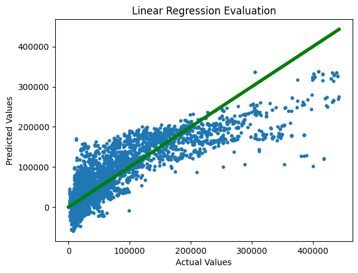

```
The R-squared of the Random Forest Model Train is 99.84
The R-squared of the Random Forest Model Test is 98.93
```

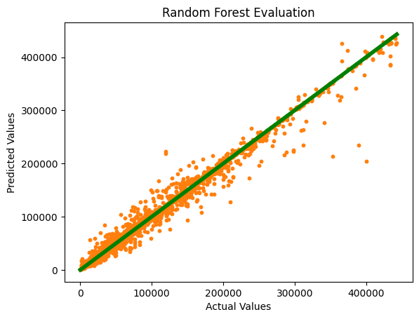

```
The R-squared of the Gradient Boost Model Train is 87.35
The R-squared of the Gradient Boost Model Test is 86.10
```

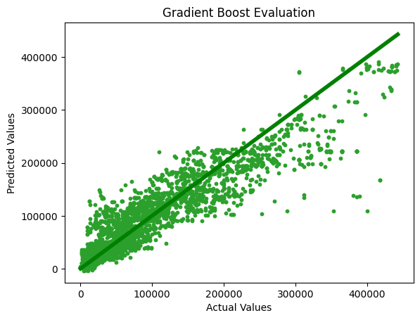

```
The R-squared of the XGBoost Model Train is 98.71
The R-squared of the XGBoost Model Test is 97.86
```

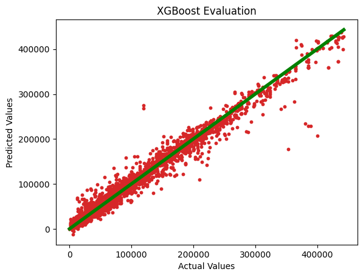

```
The R-squared of the KNN Model Train is 99.31
The R-squared of the KNN Model Test is 98.94
```

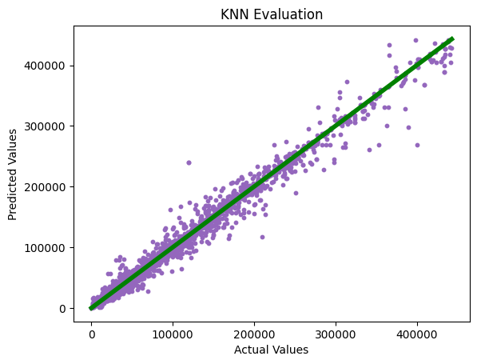

```
The R-squared of the Decision Tree Model Train is 100.00
The R-squared of the Decision Tree Model Test is 98.46
```

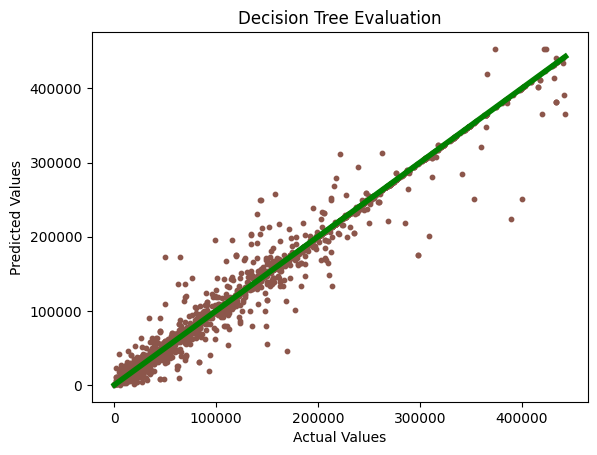

```
The R-squared of the Bagging Regressor Model Train is 99.84
The R-squared of the Bagging Regressor Model Test is 98.91
```

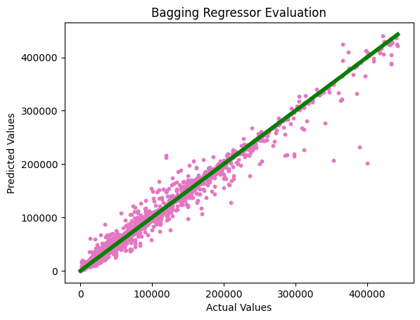

```python
results = []

models = [
    ('Linear Regression', LinearRegression()),
    ('Random Forest', RandomForestRegressor(random_state=42)),
    ('Gradient Boost', GradientBoostingRegressor(n_estimators=100, learning_rate=0.1, max_depth=3, random_state=42)),
    ('XGBoost', XGBRegressor(random_state=42)),
    ('KNN', KNeighborsRegressor(n_neighbors=5)),
    ('Decision Tree', DecisionTreeRegressor(random_state=42)),
    ('Bagging Regressor', BaggingRegressor(n_estimators=150, random_state=42))
]

colors = ['#1f77b4', '#ff7f0e', '#2ca02c', '#d62728', '#9467bd', '#8c564b', '#e377c2']

for i, (name, model) in enumerate(models):
    model.fit(X_train, y_train)
    y_pred = model.predict(X_test)
    r2 = model.score(X_test, y_test)  # R-squared value
    mse = mean_squared_error(y_test, y_pred)
    results.append((name, r2, mse))

    acc_train = model.score(X_train, y_train) * 100
    acc_test = model.score(X_test, y_test) * 100
    print(f'The R-squared of the {name} Model Train is {acc_train:.2f}')
    print(f'The R-squared of the {name} Model Test is {acc_test:.2f}')

    plt.scatter(y_test, y_pred, s=10, color=colors[i % len(colors)])
    plt.xlabel('Actual Values')
    plt.ylabel('Predicted Values')
    plt.plot([min(y_test), max(y_test)], [min(y_test), max(y_test)], color='green', linewidth=4)
    plt.title(f'{name} Evaluation')
    plt.show()
```

## 6.3. Evaluating the model's performance

```python
dff = pd.DataFrame(results, columns=['Model', 'R2_score', 'MSE'])
df_styled_best = dff.style.highlight_max(subset=['R2_score'], color='blue') \
    .highlight_min(subset=['MSE'], color='green') \
    .highlight_max(subset=['MSE'], color='red') \
    .highlight_min(subset=['R2_score'], color='red')

display(df_styled_best)
```

|  | Model | R2_score | MSE |
| --- | --- | --- | --- |
| 0 | Linear Regression | 0.737006 | 1818959446.541932 |
| 1 | Random Forest | 0.989275 | 74176747.833993 |
| 2 | Gradient Boost | 0.860973 | 961561546.083940 |
| 3 | XGBoost | 0.978632 | 147786544.847942 |
| 4 | KNN | 0.989448 | 72981499.982403 |
| 5 | Decision Tree | 0.984553 | 106839378.697719 |
| 6 | Bagging Regressor | 0.989122 | 75237860.517558 |

## 6.4. Conclusion

Overall: KNN (K-Nearest Neighbors): This model performs exceptionally well, with an R² score similar to Random Forest and the lowest MSE among all models. It is likely the best performing model on this dataset.

R² Score: 0.989448 MSE: 72,981,499.982403

Best Models: Random Forest, KNN, and Bagging Regressor all show excellent performance with high R² scores and low MSE values.  
Weaker Models: Linear Regression and Gradient Boost have lower R² scores and higher MSE values, indicating they might not be as suitable for this dataset.